# Engajamento dos parlamentares no Twitter

## Os dados

Leitura dos dados da atividade dos parlamentares em 2019.

```r
atividade = read_projectdata()

glimpse(atividade)
```

```
## Observations: 608
## Variables: 19
## $ id_parlamentar        <chr> "204554", "204521", "204379", "204560", ...
## $ casa                  <chr> "câmara", "câmara", "câmara", "câmara", ...
## $ nome_eleitoral        <chr> "ABÍLIO SANTANA", "ABOU ANNI", "ACÁCIO F...
## $ partido               <chr> "PR", "PSL", "PROS", "PSDB", "NOVO", "PP...
## $ UF                    <chr> "BA", "SP", "AP", "BA", "SP", "GO", "MG"...
## $ twitter               <chr> "AbilioSantana_", "abouannipv", "Favacho...
## $ seguidores            <dbl> NA, NA, NA, NA, 4652, NA, NA, NA, NA, NA...
## $ segue                 <dbl> NA, NA, NA, NA, 315, NA, NA, NA, NA, NA,...
## $ n_proprio             <dbl> 0, 0, 0, 0, 99, 0, 0, 0, 0, 0, 0, 0, NA,...
## $ n_retweet             <dbl> 0, 0, 0, 0, 9, 0, 0, 0, 0, 0, 0, 0, NA, ...
## $ engaj_total           <dbl> 0, 0, 0, 0, 7090, 0, 0, 0, 0, 0, 0, 0, N...
## $ engaj_total_proprio   <dbl> 0, 0, 0, 0, 6701, 0, 0, 0, 0, 0, 0, 0, N...
## $ engaj_total_retweet   <dbl> 0, 0, 0, 0, 389, 0, 0, 0, 0, 0, 0, 0, NA...
## $ engaj_mediano         <dbl> 0.0, 0.0, 0.0, 0.0, 26.5, 0.0, 0.0, 0.0,...
## $ engaj_mediano_proprio <dbl> 0.0, 0.0, 0.0, 0.0, 22.5, 0.0, 0.0, 0.0,...
## $ engaj_mediano_retweet <dbl> 0.0, 0.0, 0.0, 0.0, 0.0, 0.0, 0.0, 0.0, ...
## $ engaj_max             <dbl> 0, 0, 0, 0, 1031, 0, 0, 0, 0, 0, 0, 0, N...
## $ engaj_max_proprio     <dbl> 0, 0, 0, 0, 1031, 0, 0, 0, 0, 0, 0, 0, N...
## $ engaj_max_retweet     <dbl> 0, 0, 0, 0, 99, 0, 0, 0, 0, 0, 0, 0, NA,...
```

Removendo NA das colunas a serem usadas na regressão, já que apenas é possível gerar o modelo a partir de dados numéricos.

```r
parlamentares_twitter = atividade  %>%
  filter(!is.na(twitter) & !is.na(segue)) %>%
  mutate(tuitou = !is.na(twitter) & (n_proprio + n_retweet > 0))

glimpse(parlamentares_twitter)
```

```
## Observations: 370
## Variables: 20
## $ id_parlamentar        <chr> "204528", "178836", "160559", "204545", ...
## $ casa                  <chr> "câmara", "câmara", "câmara", "câmara", ...
## $ nome_eleitoral        <chr> "ADRIANA VENTURA", "ALAN RICK", "ALCEU M...
## $ partido               <chr> "NOVO", "DEM", "MDB", "PSL", "PT", "PSL"...
## $ UF                    <chr> "SP", "AC", "RS", "MG", "SP", "SP", "SP"...
## $ twitter               <chr> "adrianasounovo", "Alan_Rick", "Alceu_Mo...
## $ seguidores            <dbl> 4652, 3983, 6370, 464, 6447, 161745, 113...
## $ segue                 <dbl> 315, 995, 434, 267, 3253, 2015, 140, 103...
## $ n_proprio             <dbl> 99, 49, 214, 39, 346, 830, 58, 485, 1, 2...
## $ n_retweet             <dbl> 9, 1, 30, 4, 100, 169, 15, 204, 1, 95, 4...
## $ engaj_total           <dbl> 7090, 4286, 6852, 10231, 69348, 566011, ...
## $ engaj_total_proprio   <dbl> 6701, 284, 2239, 186, 47967, 320063, 23,...
## $ engaj_total_retweet   <dbl> 389, 4002, 4613, 10045, 21381, 245948, 7...
## $ engaj_mediano         <dbl> 26.5, 4.0, 8.0, 4.0, 16.5, 134.0, 0.0, 4...
## $ engaj_mediano_proprio <dbl> 22.5, 4.0, 8.0, 4.0, 12.0, 60.0, 0.0, 27...
## $ engaj_mediano_retweet <dbl> 0.0, 0.0, 0.0, 0.0, 0.0, 0.0, 0.0, 0.0, ...
## $ engaj_max             <dbl> 1031, 4002, 4227, 8171, 12335, 20348, 4,...
## $ engaj_max_proprio     <dbl> 1031, 38, 136, 14, 12335, 7271, 4, 3643,...
## $ engaj_max_retweet     <dbl> 99, 4002, 4227, 8171, 8623, 20348, 2, 33...
## $ tuitou                <lgl> TRUE, TRUE, TRUE, TRUE, TRUE, TRUE, TRUE...
```

## Relações entre as características do parlamentar e o engajamento total

As características relevantes a serem consideradas para o modelo são: qual a casa (senado/câmara) do parlamentar, quantas pessoas ele segue, por quantas ele é seguido, quanto ele tuíta e quanto ele retuíta.

### Distribuição das Probabilidades

Para a variável categórica `casa`, os dados estão dentro do esperado, sendo os únicos valores existentes `câmara` e `senado`.

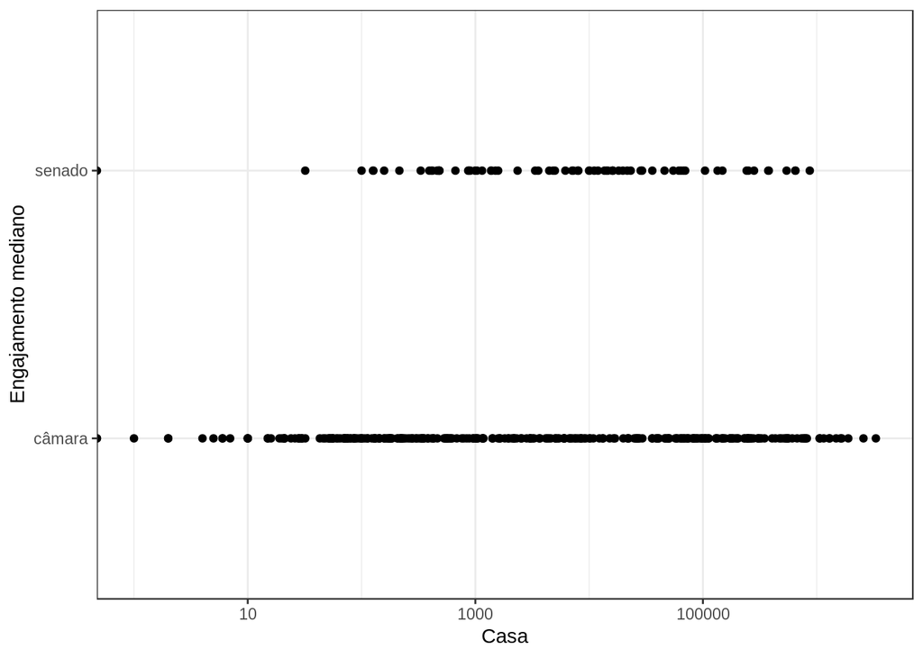

```r
parlamentares_twitter %>%
  ggplot(aes(engaj_total, casa)) +
  geom_point() +
  scale_x_log10()+
  labs(x="Casa", y="Engajamento mediano")
```

Para os demais dados, é preciso aplicar a operação logarítmica na base 10 para que seja plausível o uso de uma reta para explicá-los.

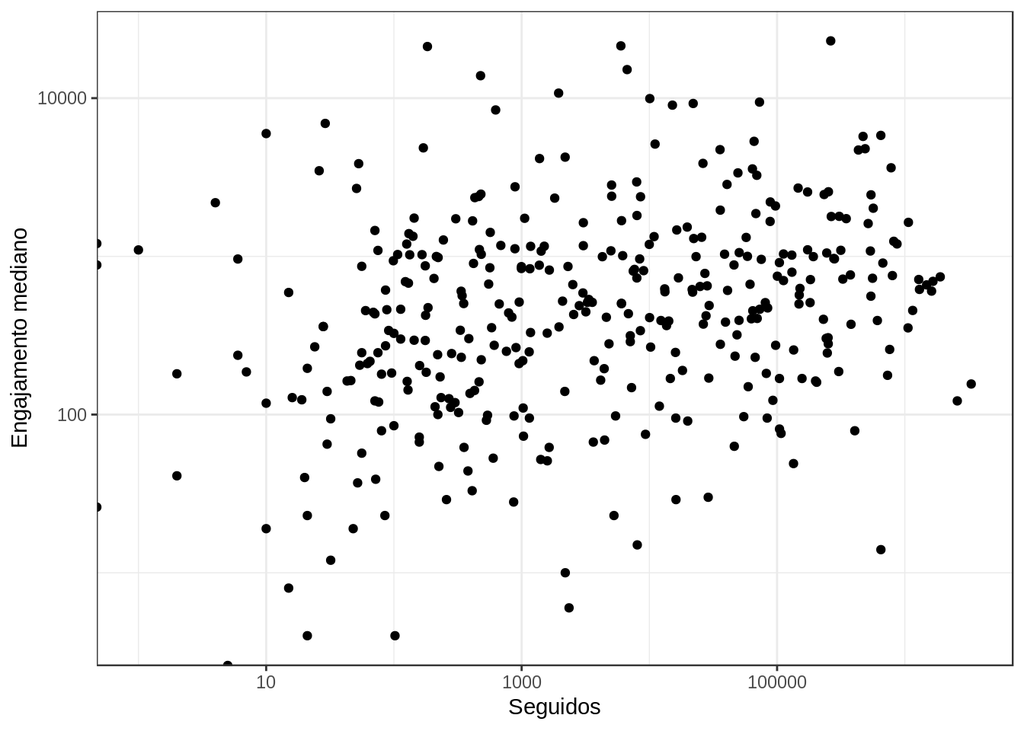

```r
parlamentares_twitter %>%
  ggplot(aes(engaj_total, segue)) +
  geom_point() +
  scale_x_log10()+
  scale_y_log10()+
  labs(x="Seguidos", y="Engajamento mediano")
```

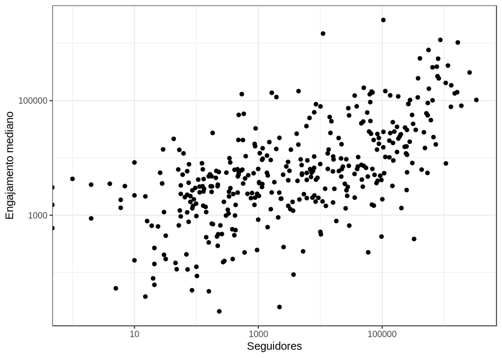

```r
parlamentares_twitter %>%
  ggplot(aes(engaj_total, seguidores)) +
  geom_point() +
  scale_x_log10()+
  scale_y_log10()+
  labs(x="Seguidores", y="Engajamento mediano")
```

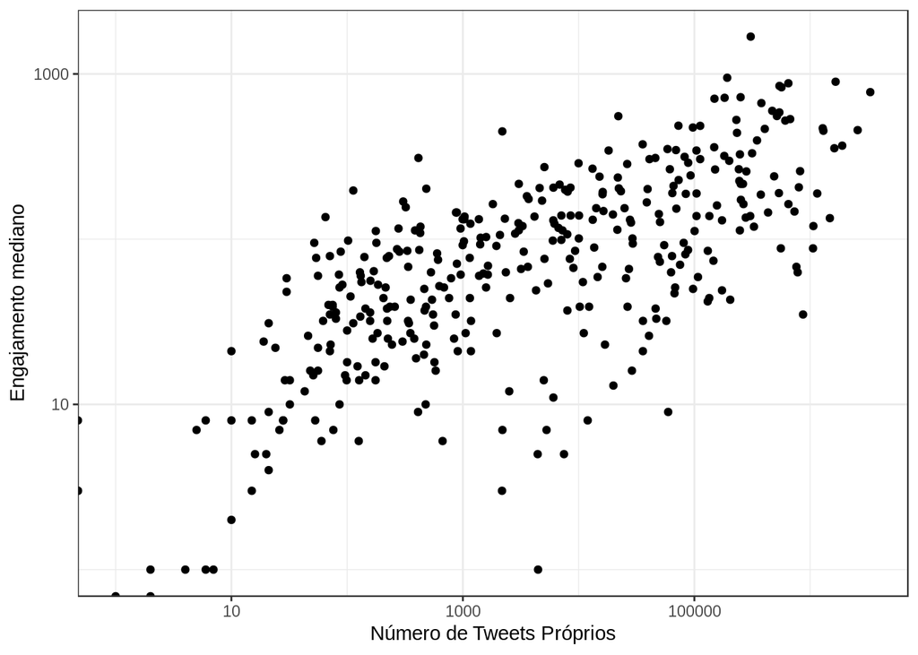

```r
parlamentares_twitter %>%
  ggplot(aes(engaj_total,n_proprio)) +
  geom_point() +
  scale_x_log10()+
  scale_y_log10()+
  labs(x="Número de Tweets Próprios", y="Engajamento mediano")
```

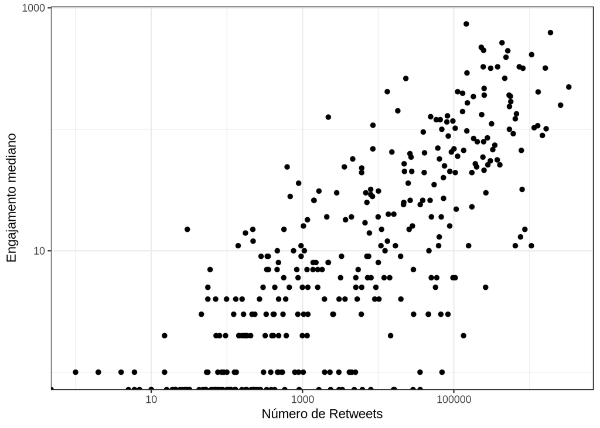

```r
parlamentares_twitter %>%
  ggplot(aes(engaj_total,n_retweet)) +
  geom_point() +
  scale_x_log10()+
  scale_y_log10()+
  labs(x="Número de Retweets", y="Engajamento mediano")
```

Logo, para tranformá-las para logarítmo na base 10, foi feita, anteriormente, a adição a 1 a fim de evitar que resultasse em infinito.

```r
parlamentares_twitter_log = parlamentares_twitter %>%
  mutate(engaj_total_log = log10(engaj_total+1),
         segue_log = log10(segue+1),
           seguidores_log = log10(seguidores+1),
           n_retweet_log = log10(n_retweet+1),
           n_proprio_log = log10(n_proprio+1))
```

### Modelo de Regressão Linear para o Engajamento Total

```r
lm_total4 = lm(engaj_total_log ~ segue_log + seguidores_log +  n_retweet_log + n_proprio_log + casa,
   data=parlamentares_twitter_log)

tidy(lm_total4, conf.int = T)
```

```
## # A tibble: 6 x 7
##   term           estimate std.error statistic  p.value conf.low conf.high
##   <chr>             <dbl>     <dbl>     <dbl>    <dbl>    <dbl>     <dbl>
## 1 (Intercept)      -0.124    0.214     -0.580 5.62e- 1  -0.545      0.297
## 2 segue_log        -0.262    0.0647    -4.06  6.09e- 5  -0.390     -0.135
## 3 seguidores_log    0.550    0.0530    10.4   2.57e-22   0.446      0.654
## 4 n_retweet_log     0.937    0.0658    14.3   5.94e-37   0.808      1.07
## 5 n_proprio_log     0.735    0.0867     8.48  5.57e-16   0.565      0.906
## 6 casasenado        0.114    0.0956     1.20  2.32e- 1  -0.0735     0.302
```

```r
glance(lm_total4)
```

```
## # A tibble: 1 x 11
##   r.squared adj.r.squared sigma statistic   p.value    df logLik   AIC
## *     <dbl>         <dbl> <dbl>     <dbl>     <dbl> <int>  <dbl> <dbl>
## 1     0.766         0.763 0.713      239. 1.75e-112     6  -397.  807.
## # ... with 3 more variables: BIC <dbl>, deviance <dbl>, df.residual <int>
```

Pela descrição do modelo acima, vê-se que a quantidade de retweets e de tweets próprios são os principais fatores relacionados com o engajamento total, com o coeficiente chegando próximo a 1 quando considerado os intervalos de confiança.

Por fim, o atributo `casa` possui a menor magnitude de coeficiente no modelo. Olhando o intervalo de confiança, ele é o único que pode não influenciar no modelo, já que o zero está incluso.

O R² ajustado mostra um bom modelo que explica, aproximadamente, 76% dos dados.

### Visualizando o modelo

Para visualizar um modelo de regressão múltipla facilmente, podemos fixar os valores de algumas variáveis e deixar outras livres. Nesta análise foram varidos o número de tweets que não são retweets ou retweets com comentário e a casa. Logo o número de pessoas que são seguidas e que seguem a conta do político e o número de retweets foram fixados na média de cada um deles.

```r
para_plotar_modelo = parlamentares_twitter_log %>%
  data_grid(n_proprio_log = seq_range(n_proprio_log, 10),
            segue_log = mean(segue_log),
            seguidores_log = mean(seguidores_log),
            n_retweet_log = mean(n_retweet_log),
            casa = c("câmara", "senado")) %>%
  add_predictions(lm_total4)
glimpse(para_plotar_modelo)
```

```
## Observations: 20
## Variables: 6
## $ n_proprio_log  <dbl> 0,0000000, 0,0000000, 0,3584538, 0,3584538, 0,7...
## $ segue_log      <dbl> 2,64516, 2,64516, 2,64516, 2,64516, 2,64516, 2,...
## $ seguidores_log <dbl> 3,751369, 3,751369, 3,751369, 3,751369, 3,75136...
## $ n_retweet_log  <dbl> 0,9847925, 0,9847925, 0,9847925, 0,9847925, 0,9...
## $ casa           <chr> "câmara", "senado", "câmara", "senado", "câmara...
## $ pred           <dbl> 2,169080, 2,283468, 2,432719, 2,547106, 2,69635...
```

Visualizando os valores tranformados, na escala logarítmica:

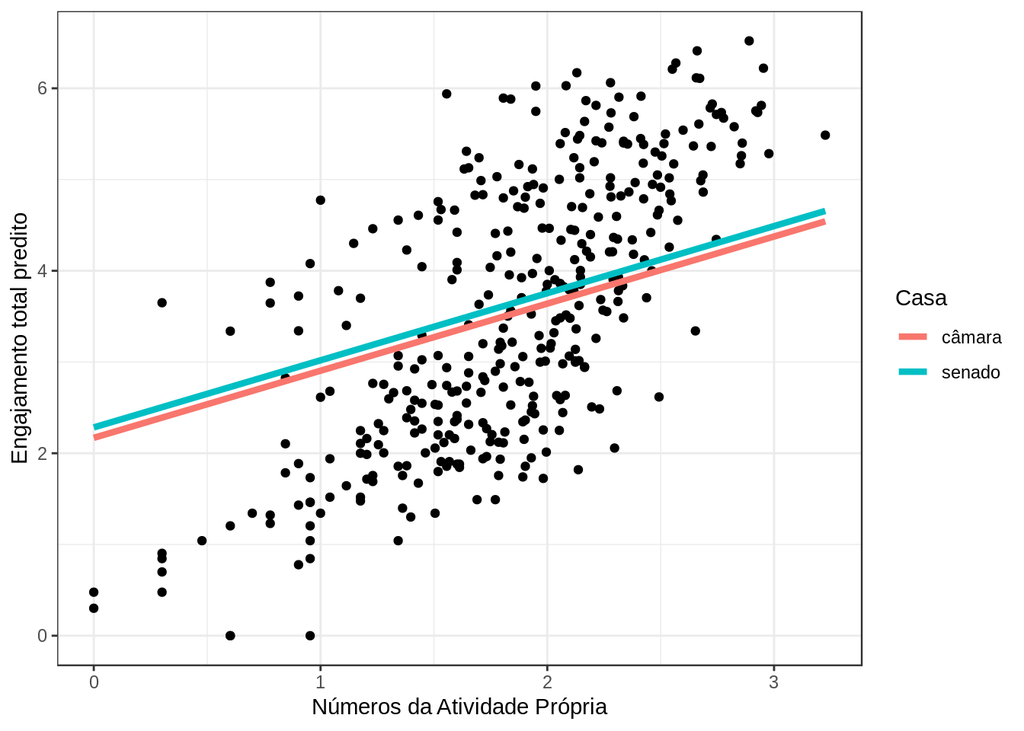

```r
ggplot(data = parlamentares_twitter_log, aes(x = n_proprio_log)) +
  geom_point(aes(y = engaj_total_log)) +
  geom_line(data = para_plotar_modelo, aes(y = pred, color=casa), size = 1.5) +
  labs(x="Números da Atividade Própria", y="Engajamento total predito", color="Casa")
```

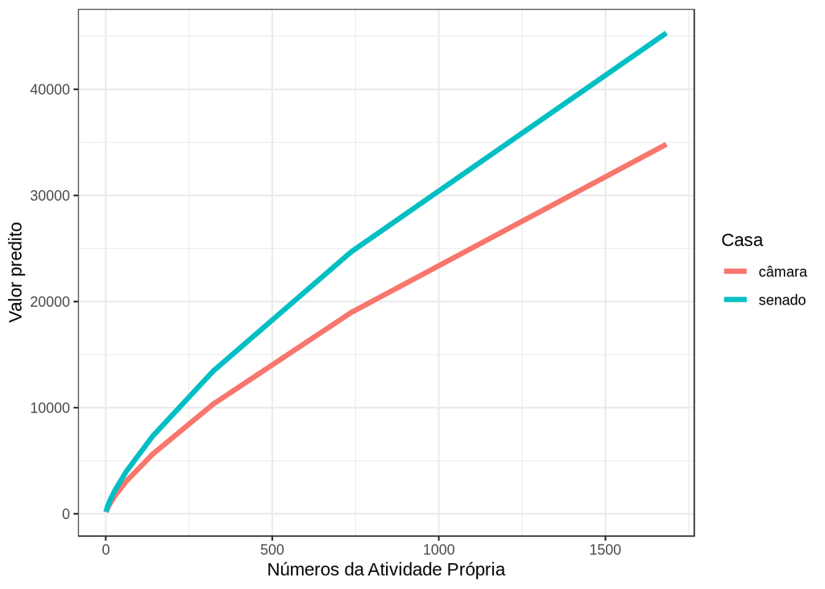

```r
ggplot(data = parlamentares_twitter_log, aes(x = 10**n_proprio_log)) +
  geom_line(data = para_plotar_modelo, aes(y = 10**pred,color=casa), size = 1.5) +
  labs(x="Números da Atividade Própria", y="Valor predito", color="Casa")
```

## Engajamento mediano

Faremos a mesma análise considerando o engajamento mediano dos representantes. Portanto, começaremos imprimindo os gráficos para a análise visual da distribuição dos dados e investigação de anormalidades.

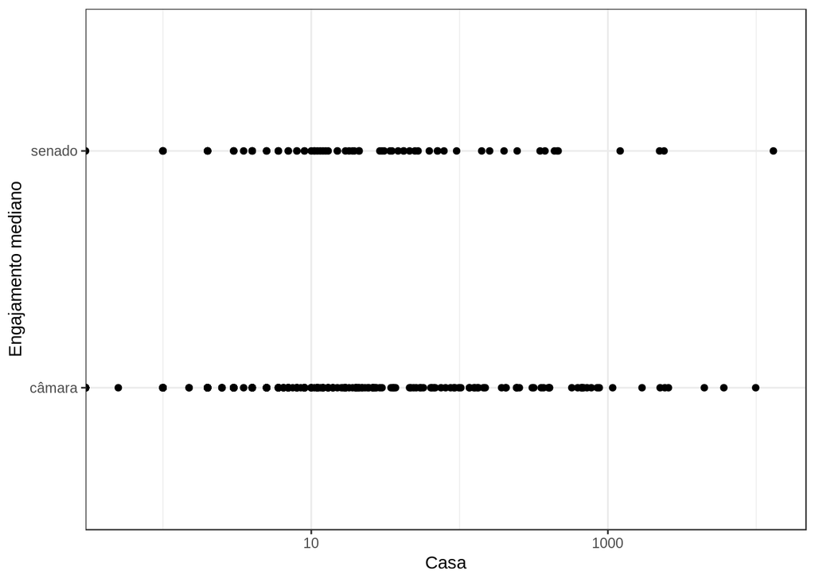

```r
parlamentares_twitter %>%
  ggplot(aes(engaj_mediano, casa)) +
  geom_point() +
  scale_x_log10()+
  labs(x="Casa", y="Engajamento mediano")
```

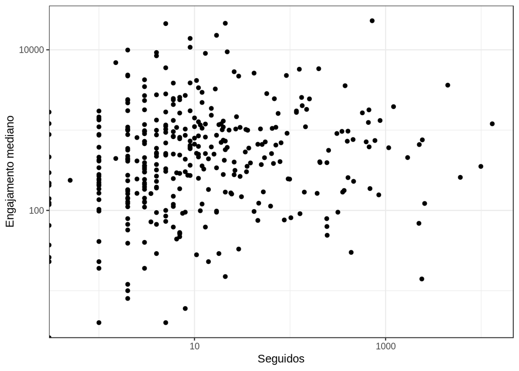

```r
parlamentares_twitter %>%
  ggplot(aes(engaj_mediano, segue)) +
  geom_point() +
  scale_x_log10()+
  scale_y_log10()+
  labs(x="Seguidos", y="Engajamento mediano")
```

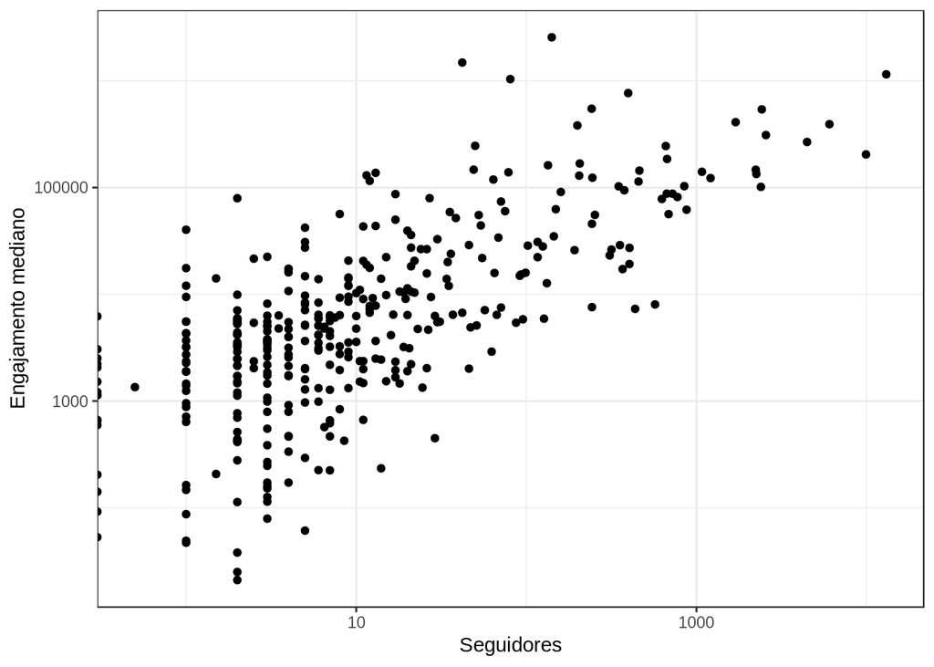

```r
parlamentares_twitter %>%
  ggplot(aes(engaj_mediano, seguidores)) +
  geom_point() +
  scale_x_log10()+
  scale_y_log10()+
  labs(x="Seguidores", y="Engajamento mediano")
```

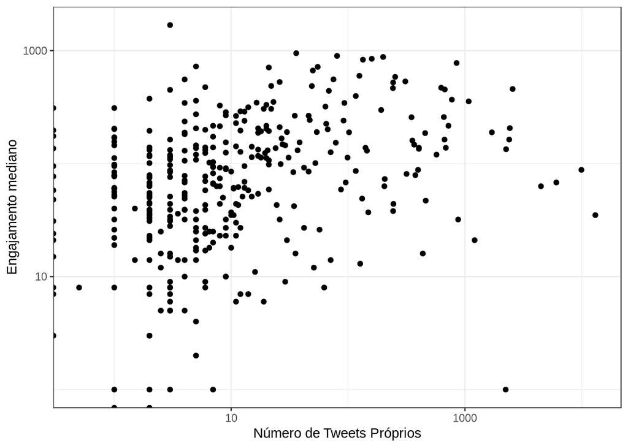

```r
parlamentares_twitter %>%
  ggplot(aes(engaj_mediano,n_proprio)) +
  geom_point() +
  scale_x_log10()+
  scale_y_log10()+
  labs(x="Número de Tweets Próprios", y="Engajamento mediano")
```

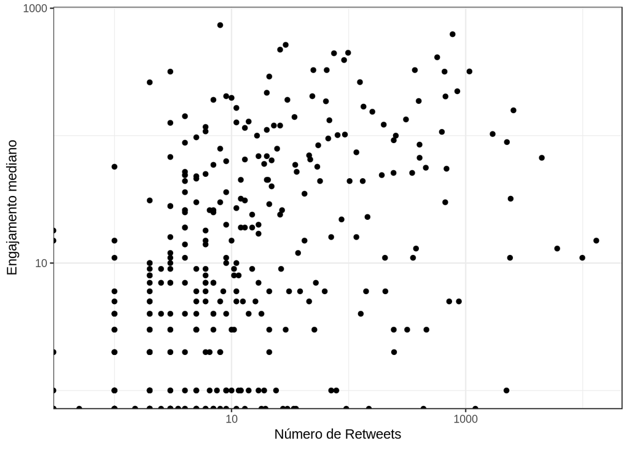

```r
parlamentares_twitter %>%
  ggplot(aes(engaj_mediano,n_retweet)) +
  geom_point() +
  scale_x_log10()+
  scale_y_log10()+
  labs(x="Número de Retweets", y="Engajamento mediano")
```

Ao contrário do que foi visto para a variável resposta anterior, os dados se apresentam mais dispersos, denunciando uma correlação mais baixa delas com o engajamento mediano. Mas a quantidade de seguidores mostrou-se com uma tendência crescente de forma forte.

Faremos, também, como anteriormente transformando o enjamento mediano para o seu logarítmo na base 10.

```r
parlamentares_twitter_log = parlamentares_twitter_log %>%
  mutate(engaj_mediano_log = log10(engaj_mediano + 1 ))
```

```r
lm_mediano1 = lm(engaj_mediano_log ~ segue_log,
   data=parlamentares_twitter_log)

lm_mediano2 = lm(engaj_mediano_log ~ segue_log + seguidores_log,
   data=parlamentares_twitter_log)

lm_mediano3 = lm(engaj_mediano_log ~ segue_log + seguidores_log +  n_retweet_log,
   data=parlamentares_twitter_log)

lm_mediano4 = lm(engaj_mediano_log ~ segue_log + seguidores_log +  n_retweet_log + n_proprio_log + casa,
   data=parlamentares_twitter_log)
```

```r
tidy(lm_mediano1)
```

```
## # A tibble: 2 x 5
##   term        estimate std.error statistic   p.value
##   <chr>          <dbl>     <dbl>     <dbl>     <dbl>
## 1 (Intercept)    0.696    0.175       3.97 0.0000849
## 2 segue_log      0.164    0.0643      2.54 0.0114
```

```r
glance(lm_mediano1)
```

```
## # A tibble: 1 x 11
##   r.squared adj.r.squared sigma statistic p.value    df logLik   AIC   BIC
## *     <dbl>         <dbl> <dbl>     <dbl>   <dbl> <int>  <dbl> <dbl> <dbl>
## 1    0.0173        0.0146 0.801      6.47  0.0114     2  -442.  890.  901.
## # ... with 2 more variables: deviance <dbl>, df.residual <int>
```

```r
tidy(lm_mediano2)
```

```
## # A tibble: 3 x 5
##   term           estimate std.error statistic  p.value
##   <chr>             <dbl>     <dbl>     <dbl>    <dbl>
## 1 (Intercept)      -0.956    0.146      -6.52 2.27e-10
## 2 segue_log        -0.254    0.0491     -5.18 3.70e- 7
## 3 seguidores_log    0.735    0.0366     20.1  5.71e-61
```

```r
glance(lm_mediano2)
```

```
## # A tibble: 1 x 11
##   r.squared adj.r.squared sigma statistic  p.value    df logLik   AIC   BIC
## *     <dbl>         <dbl> <dbl>     <dbl>    <dbl> <int>  <dbl> <dbl> <dbl>
## 1     0.531         0.529 0.554      208. 4.07e-61     3  -305.  618.  633.
## # ... with 2 more variables: deviance <dbl>, df.residual <int>
```

```r
tidy(lm_mediano3)
```

```
## # A tibble: 4 x 5
##   term           estimate std.error statistic  p.value
##   <chr>             <dbl>     <dbl>     <dbl>    <dbl>
## 1 (Intercept)      -0.758    0.144      -5.28 2.26e- 7
## 2 segue_log        -0.306    0.0477     -6.42 4.28e-10
## 3 seguidores_log    0.655    0.0374     17.5  2.36e-50
## 4 n_retweet_log     0.242    0.0400      6.04 3.77e- 9
```

```r
glance(lm_mediano3)
```

```
## # A tibble: 1 x 11
##   r.squared adj.r.squared sigma statistic  p.value    df logLik   AIC   BIC
## *     <dbl>         <dbl> <dbl>     <dbl>    <dbl> <int>  <dbl> <dbl> <dbl>
## 1     0.574         0.570 0.529      164. 1.93e-67     4  -287.  585.  604.
## # ... with 2 more variables: deviance <dbl>, df.residual <int>
```

```r
tidy(lm_mediano4, conf.int = T)
```

```
## # A tibble: 6 x 7
##   term           estimate std.error statistic  p.value conf.low conf.high
##   <chr>             <dbl>     <dbl>     <dbl>    <dbl>    <dbl>     <dbl>
## 1 (Intercept)    -0.664      0.159     -4.19  3.57e- 5   -0.977   -0.352
## 2 segue_log      -0.305      0.0480    -6.34  6.61e-10   -0.399   -0.210
## 3 seguidores_log  0.664      0.0393    16.9   9.80e-48    0.587    0.742
## 4 n_retweet_log   0.279      0.0488     5.71  2.30e- 8    0.183    0.375
## 5 n_proprio_log  -0.0906     0.0643    -1.41  1.60e- 1   -0.217    0.0359
## 6 casasenado     -0.00805    0.0709    -0.114 9.10e- 1   -0.148    0.131
```

```r
glance(lm_mediano4)
```

```
## # A tibble: 1 x 11
##   r.squared adj.r.squared sigma statistic  p.value    df logLik   AIC   BIC
## *     <dbl>         <dbl> <dbl>     <dbl>    <dbl> <int>  <dbl> <dbl> <dbl>
## 1     0.576         0.570 0.529      99.0 1.17e-65     6  -286.  586.  614.
## # ... with 2 more variables: deviance <dbl>, df.residual <int>
```

Bem como poderia ser visto nos gráficos iniciais, os dados explicam fracamente o engajamento médio, de modo que o R² ajustado é de 57%. A casa e o número de tweets próprios admitem coeficiente zero, sendo pouco explicativos. Enquanto que o número de contas seguidas contribui negativamente com o engajamento mediano, com magnitude aproximada ao número de retweets. Já o número de seguidores é o principal fator relacionado, como visto anteriormente.

### Visualizando o modelo

```r
para_plotar_modelo = parlamentares_twitter_log %>%
  data_grid(n_proprio_log = seq_range(n_proprio_log, 10),
            segue_log = mean(segue_log),
            seguidores_log = mean(seguidores_log),
            n_retweet_log = mean(n_retweet_log),
            casa = c("câmara", "senado")) %>%
  add_predictions(lm_mediano4)
glimpse(para_plotar_modelo)
```

```
## Observations: 20
## Variables: 6
## $ n_proprio_log  <dbl> 0,0000000, 0,0000000, 0,3584538, 0,3584538, 0,7...
## $ segue_log      <dbl> 2,64516, 2,64516, 2,64516, 2,64516, 2,64516, 2,...
## $ seguidores_log <dbl> 3,751369, 3,751369, 3,751369, 3,751369, 3,75136...
## $ n_retweet_log  <dbl> 0,9847925, 0,9847925, 0,9847925, 0,9847925, 0,9...
## $ casa           <chr> "câmara", "senado", "câmara", "senado", "câmara...
## $ pred           <dbl> 1,2967821, 1,2887286, 1,2643085, 1,2562550, 1,2...
```

Visualizando as predições com os dados, vê-se que a natureza destes não é explicável pela regressão obtida:

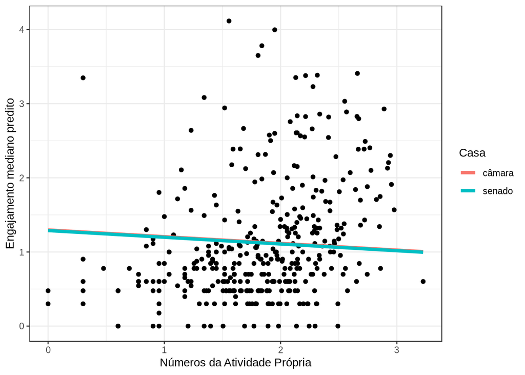

```r
ggplot(data = parlamentares_twitter_log, aes(x = n_proprio_log)) +
  geom_point(aes(y = engaj_mediano_log)) +
  geom_line(data = para_plotar_modelo, aes(y = pred, color=casa), size = 1.5) +
  labs(x="Números da Atividade Própria", y="Engajamento mediano predito", color="Casa")
```